# Lab assignment 6

```r
library(tidyverse)
library(lubridate)
library(viridis)
library(colorspace)
```

## Playing with palettes

Build your own palette of colors! You can start from online tools such as

- https://image-color.com/ to extract dominant colors from pictures
- https://medialab.github.io/iwanthue/ to get an initial choice of colors
- http://tristen.ca/hcl-picker/ to build smooth color gradients in HCL space
- https://projects.susielu.com/viz-palette to evaluate the properties of the palette, including color blindness.

Add your colors as hex codes (like `"#5778a4"`) in the vector in the following code block:

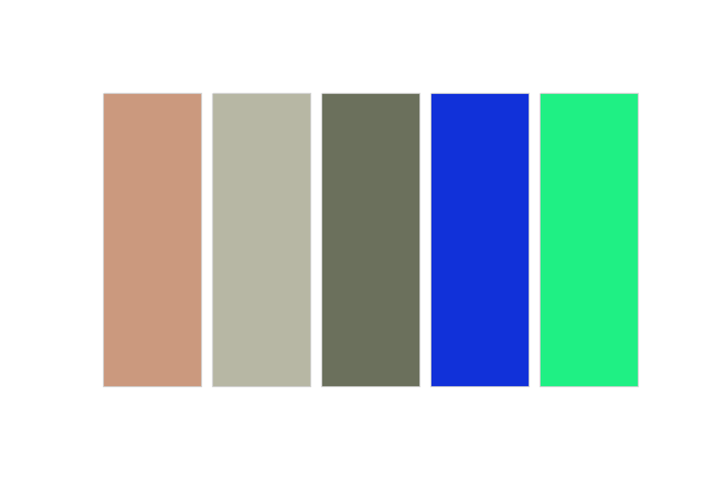

```r
my_colors <- c(
  # Write your colors here
  "#CB997E","#B7B7A4","#6B705C","#1131D9","#1FF084"
)
swatchplot(my_colors)
```

And then observe the characteristics of your palette using the plot below.

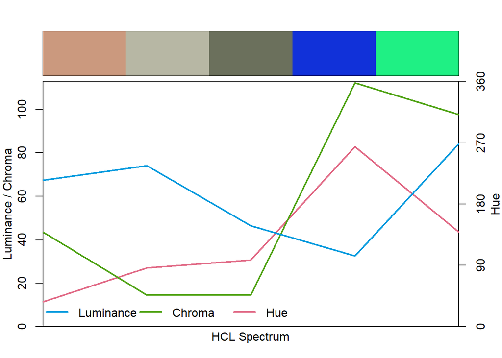

```r
specplot(my_colors)
```

Based on the last plot, which properties does your color palette has? Which type of data can it encode? Would it print well in black and white?

## Rolling vaccinations

The website [Our World in Data](https://ourworldindata.org) maintains a daily updated csv file containing a lot of covid-related metrics, including vaccinations. Refer to [this page](https://ourworldindata.org/covid-vaccinations) for further information about this dataset.

```r
# Download the file only if it doesn't exist locally, to save time
path <- "owid-covid-data.csv"
if (!file.exists(path)) {
  download.file("https://covid.ourworldindata.org/data/owid-covid-data.csv",
                path)
}
covid <- read_csv(path) %>%
  filter(continent == "Europe") %>%
  filter(date > "2021-01-01")
```

We are going to focus only on European countries, since the university is based in Europe. However, if you are from other parts of the world, you are welcome to pick your continent from the dataset, and continue the exercise with it.

Among the several quantities recorded in the dataset we are going to focus on the `new_vaccinations_smoothed_per_million` variable, which reports the rolling average of new vaccinations (to smooth out weekly variations), normalized by population (in order to make comparisons between countries meaningful).

We are going to visualize this dataset using lines. A basic visualization would be made using one colored line per country, but there are 51 distinct values for the `location` variable in the `covid` dataset. As we have discussed in class, these are too many values to be used effectively in association with color.

Therefore we will focus on a subset of countries to be represented with colors, whereas all the others will be represented in gray to provide context. In particular, the following vector `highlight` contains the names of the countries to be colored. You are free to change them, if you so wish.

```r
highlight <- c(
  "Italy",
  "Germany",
  "United Kingdom",
  "Spain",
  "Gibraltar"
)
highlight
```

```
## [1] "Italy"          "Germany"        "United Kingdom" "Spain"
## [5] "Gibraltar"
```

We will build the plot in stages, and in each stage you will have to modify/complete the code cell.

First, let’s define the basic layer, consisting of one gray line for each country. If you execute the code cell below, you will see that the result is not what we are after. You should then use the `group` aesthetic mapping to define one line for each country (which in the dataset is identified by the `location` variable), and then you should add the appropriate argument to `geom_line` to make all the lines of the color `"lightgray"`, and semi-transparent, using `alpha=0.7`. Moreover, make the lines thinner, say at size 0.5. Furthermore, change the label of the `y` axis to `"Smoothed new vaccinations per million people"`.

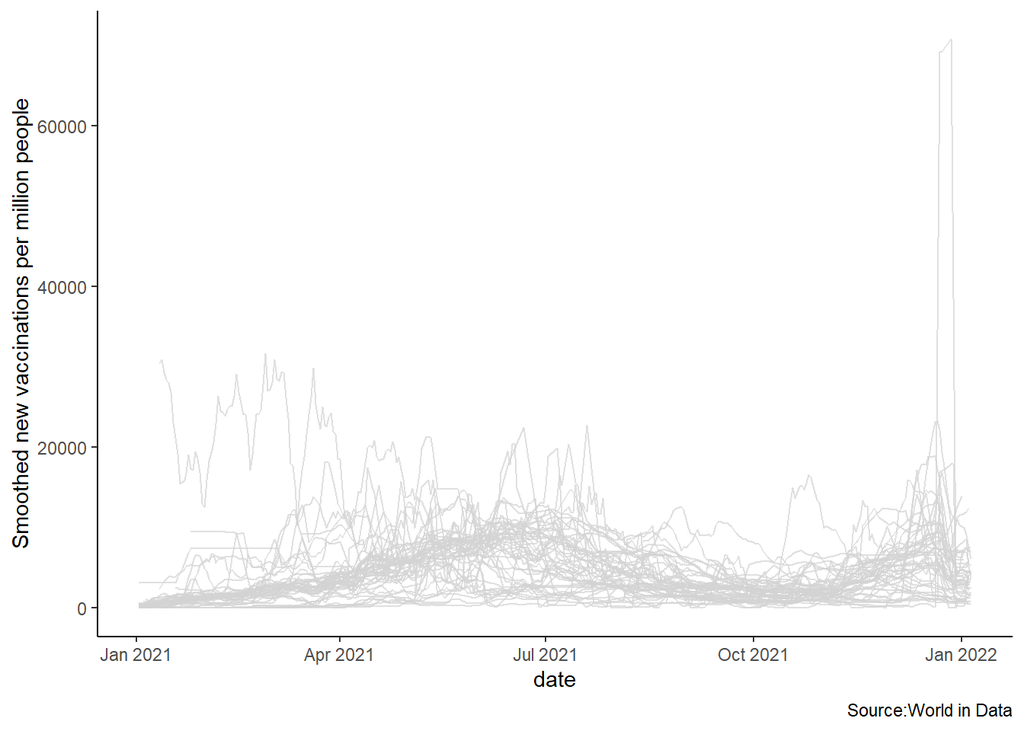

```r
base_plot <- ggplot(covid, aes(
  x=date,
  y=new_vaccinations_smoothed_per_million,
  group=location
  # Complete the arguments here
)) +
  geom_line(color="lightgray",alpha=0.7,size=0.5
    # Add appropriate arguments here
  ) +
  labs(
    y="Smoothed new vaccinations per million people",
    # Set the caption for the y axis
    caption = "Source:World in Data"
  ) +
  theme_classic()

base_plot
```

Note that we used `theme_classic()` to change the overall appearance of the plot.

Next, we can add another layer to the plot, which uses again the line geometric object but works on a restricted set of data. The code cell below specifies such a layer, but is missing the color specification. You should edit the aesthetic mapping just for that layer, in order to use the color to encode the `location` information.

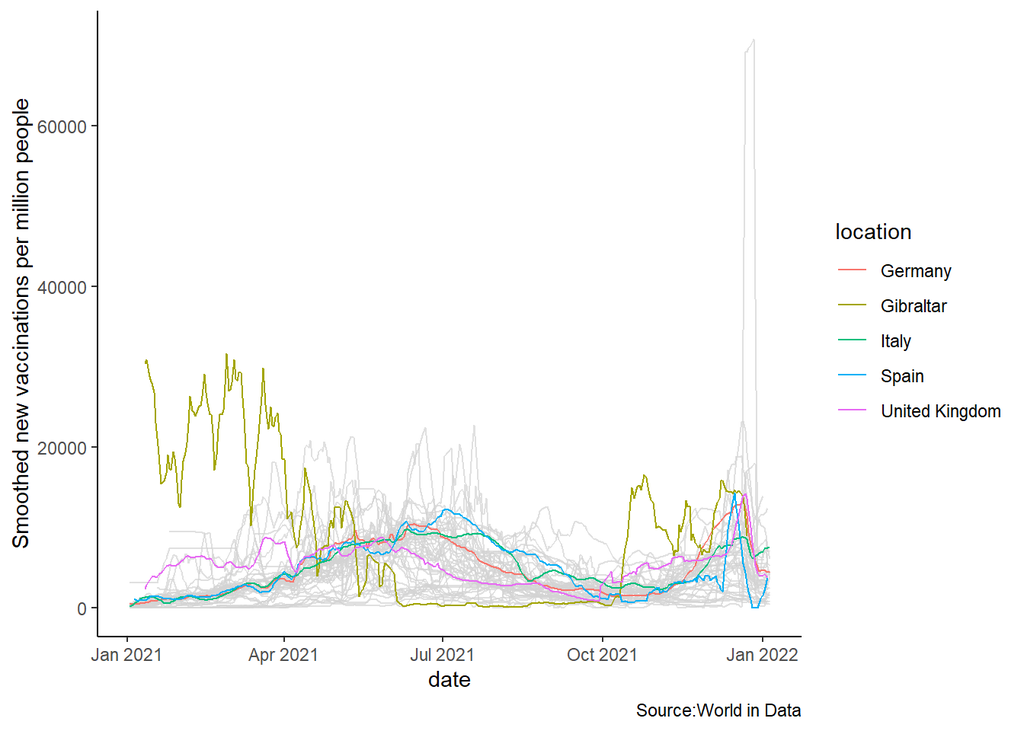

```r
base_plot + geom_line(
  data = function(d) {filter(d, location %in% highlight)},
  # Add the aesthetic mapping to color
   aes(color=location)
)
```

So far, so good. We can still improve the “popout” of the lines we want to highlight, though. In particular, we can try to add a white “aura” around each line, so that it stands out more prominently from the tangled spagetti mess of the background. To do so, modify the following snippet so that the lines, again restricted to the subset of data we want to highlight, are all colored white and with size 1.5 (you can play with different values of size, to see what happens).

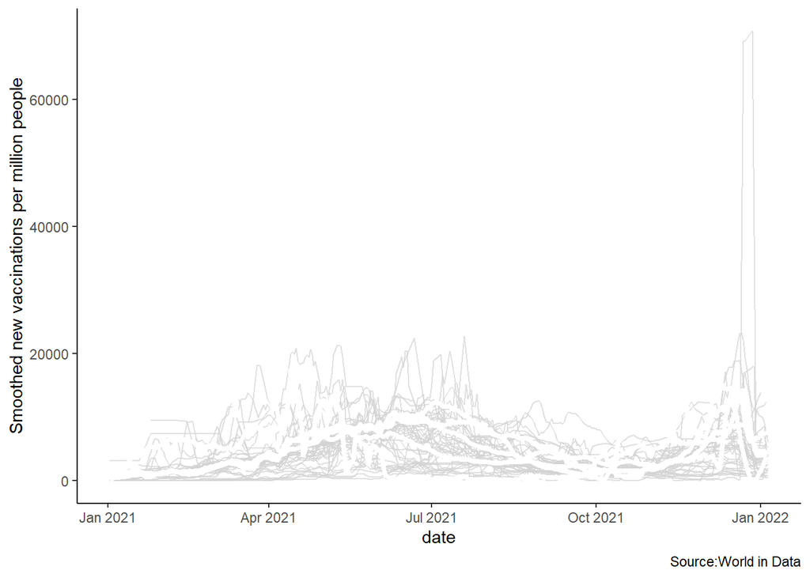

```r
base_plot + geom_line(
  data = function(d) {filter(d, location %in% highlight)},
  # Make these lines thicker (e.g. size 1.5) and white
  color="white",size=1.5
)
```

Now in the next code block add both the layers (just copy paste them) that you developed in the previous two code cells. Beware: the order matters!

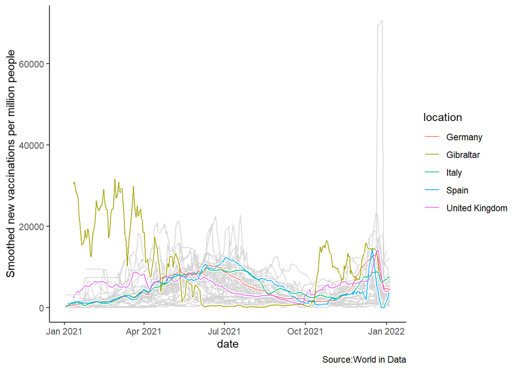

```r
highlighted_plot <- base_plot +
 geom_line(color="lightgray",alpha=0.7,size=0.5) +
  geom_line(
    # Add the layers with white thick lines and colored lines here below.
    data = function(d) {filter(d, location %in% highlight)},
    color="white",
    size=1.5
  ) +
  geom_line(
    data = function(d) {filter(d, location %in% highlight)},
    mapping=aes(color = location),
    size=0.5
  )

highlighted_plot
```

Finally, I think we could have some better colors in this plot. The default palette in this case is not ideal. Try to play with different color scales, and see if you can find one that plays better with this data. You can also look around the internet for color palettes, pasting hex codes in `scale_color_manual`.

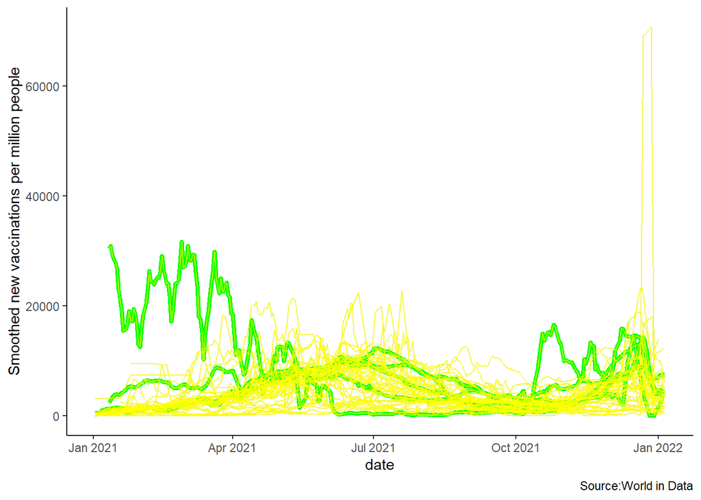

```r
highlighted_plot <- base_plot +geom_line(
data = function(d) {filter(d, location %in% highlight)},
  color="green",size=1.5)+
  geom_line(color="yellow",alpha=0.7,size=0.5
)
highlighted_plot
```